# Risk Factor Analysis

## Outcome Variable

**Outcome Variable:** stunted

## Predictor Variables

**Intervention Variable:** predfeed3

**Adjustment Set:**

unadjusted

## Stratifying Variables

The analysis was stratified on these variable(s):

- agecat
- studyid
- country

## Data Summary

| agecat | studyid | country | predfeed3 | stunted | n_cell | n |
| --- | --- | --- | --- | --- | --- | --- |
| Birth | ki0047075b-MAL-ED | BANGLADESH | 0 | 0 | 30 | 240 |
| Birth | ki0047075b-MAL-ED | BANGLADESH | 0 | 1 | 5 | 240 |
| Birth | ki0047075b-MAL-ED | BANGLADESH | 1 | 0 | 169 | 240 |
| Birth | ki0047075b-MAL-ED | BANGLADESH | 1 | 1 | 36 | 240 |
| Birth | ki0047075b-MAL-ED | BRAZIL | 0 | 0 | 73 | 185 |
| Birth | ki0047075b-MAL-ED | BRAZIL | 0 | 1 | 11 | 185 |
| Birth | ki0047075b-MAL-ED | BRAZIL | 1 | 0 | 93 | 185 |
| Birth | ki0047075b-MAL-ED | BRAZIL | 1 | 1 | 8 | 185 |
| Birth | ki0047075b-MAL-ED | INDIA | 0 | 0 | 35 | 196 |
| Birth | ki0047075b-MAL-ED | INDIA | 0 | 1 | 9 | 196 |
| Birth | ki0047075b-MAL-ED | INDIA | 1 | 0 | 130 | 196 |
| Birth | ki0047075b-MAL-ED | INDIA | 1 | 1 | 22 | 196 |
| Birth | ki0047075b-MAL-ED | NEPAL | 0 | 0 | 62 | 171 |
| Birth | ki0047075b-MAL-ED | NEPAL | 0 | 1 | 10 | 171 |
| Birth | ki0047075b-MAL-ED | NEPAL | 1 | 0 | 91 | 171 |
| Birth | ki0047075b-MAL-ED | NEPAL | 1 | 1 | 8 | 171 |
| Birth | ki0047075b-MAL-ED | PERU | 0 | 0 | 80 | 272 |
| Birth | ki0047075b-MAL-ED | PERU | 0 | 1 | 9 | 272 |
| Birth | ki0047075b-MAL-ED | PERU | 1 | 0 | 160 | 272 |
| Birth | ki0047075b-MAL-ED | PERU | 1 | 1 | 23 | 272 |
| Birth | ki0047075b-MAL-ED | SOUTH AFRICA | 0 | 0 | 129 | 233 |
| Birth | ki0047075b-MAL-ED | SOUTH AFRICA | 0 | 1 | 17 | 233 |
| Birth | ki0047075b-MAL-ED | SOUTH AFRICA | 1 | 0 | 80 | 233 |
| Birth | ki0047075b-MAL-ED | SOUTH AFRICA | 1 | 1 | 7 | 233 |
| Birth | ki0047075b-MAL-ED | TANZANIA, UNITED REPUBLIC OF | 0 | 0 | 56 | 119 |
| Birth | ki0047075b-MAL-ED | TANZANIA, UNITED REPUBLIC OF | 0 | 1 | 13 | 119 |
| Birth | ki0047075b-MAL-ED | TANZANIA, UNITED REPUBLIC OF | 1 | 0 | 45 | 119 |
| Birth | ki0047075b-MAL-ED | TANZANIA, UNITED REPUBLIC OF | 1 | 1 | 5 | 119 |
| Birth | ki1000109-EE | PAKISTAN | 0 | 0 | 0 | 4 |
| Birth | ki1000109-EE | PAKISTAN | 0 | 1 | 0 | 4 |

[output cut: 94 more lines]

The following strata were considered:

- agecat: 24 months, studyid: ki0047075b-MAL-ED, country: BANGLADESH
- agecat: 24 months, studyid: ki0047075b-MAL-ED, country: BRAZIL
- agecat: 24 months, studyid: ki0047075b-MAL-ED, country: INDIA
- agecat: 24 months, studyid: ki0047075b-MAL-ED, country: NEPAL
- agecat: 24 months, studyid: ki0047075b-MAL-ED, country: PERU
- agecat: 24 months, studyid: ki0047075b-MAL-ED, country: SOUTH AFRICA
- agecat: 24 months, studyid: ki0047075b-MAL-ED, country: TANZANIA, UNITED REPUBLIC OF
- agecat: 24 months, studyid: ki1113344-GMS-Nepal, country: NEPAL
- agecat: 24 months, studyid: kiGH5241-JiVitA-3, country: BANGLADESH
- agecat: 24 months, studyid: kiGH5241-JiVitA-4, country: BANGLADESH
- agecat: 6 months, studyid: ki0047075b-MAL-ED, country: BANGLADESH
- agecat: 6 months, studyid: ki0047075b-MAL-ED, country: BRAZIL
- agecat: 6 months, studyid: ki0047075b-MAL-ED, country: INDIA
- agecat: 6 months, studyid: ki0047075b-MAL-ED, country: NEPAL
- agecat: 6 months, studyid: ki0047075b-MAL-ED, country: PERU
- agecat: 6 months, studyid: ki0047075b-MAL-ED, country: SOUTH AFRICA
- agecat: 6 months, studyid: ki0047075b-MAL-ED, country: TANZANIA, UNITED REPUBLIC OF
- agecat: 6 months, studyid: ki1000109-EE, country: PAKISTAN
- agecat: 6 months, studyid: ki1113344-GMS-Nepal, country: NEPAL
- agecat: 6 months, studyid: kiGH5241-JiVitA-3, country: BANGLADESH
- agecat: 6 months, studyid: kiGH5241-JiVitA-4, country: BANGLADESH
- agecat: Birth, studyid: ki0047075b-MAL-ED, country: BANGLADESH
- agecat: Birth, studyid: ki0047075b-MAL-ED, country: BRAZIL
- agecat: Birth, studyid: ki0047075b-MAL-ED, country: INDIA
- agecat: Birth, studyid: ki0047075b-MAL-ED, country: NEPAL
- agecat: Birth, studyid: ki0047075b-MAL-ED, country: PERU
- agecat: Birth, studyid: ki0047075b-MAL-ED, country: SOUTH AFRICA
- agecat: Birth, studyid: ki0047075b-MAL-ED, country: TANZANIA, UNITED REPUBLIC OF
- agecat: Birth, studyid: ki1000109-EE, country: PAKISTAN
- agecat: Birth, studyid: kiGH5241-JiVitA-3, country: BANGLADESH
- agecat: Birth, studyid: kiGH5241-JiVitA-4, country: BANGLADESH

### Dropped Strata

Some strata were dropped due to rare outcomes:

- agecat: Birth, studyid: ki1000109-EE, country: PAKISTAN
- agecat: Birth, studyid: kiGH5241-JiVitA-4, country: BANGLADESH
- agecat: 6 months, studyid: ki0047075b-MAL-ED, country: BRAZIL
- agecat: 24 months, studyid: ki0047075b-MAL-ED, country: BRAZIL

## Methods Detail

We’re interested in the causal parameters $E[Y_a]$ for all values of $a \in \mathcal{A}$. These parameters represent the mean outcome if, possibly contrary to fact, we intervened to set all units to have $A=a$. Under the randomization and positivity assumptions, these are identified by the statistical parameters $\psi_a=E_W[E_{Y|A,W}(Y|A=a,W)]$. In addition, we’re interested in the mean of $Y$, $E[Y]$ under no intervention (the observed mean). We will estimate these parameters by using SuperLearner to fit the relevant likelihood factors – $E_{Y|A,W}(Y|A=a,W)$ and $p(A=a|W)$, and then updating our likelihood fit using a joint TMLE.

For unadjusted analyses ($W=\{\}$), initial likelihoods were estimated using Lrnr_glm to estimate the simple $E(Y|A)$ and Lrnr_mean to estimate $p(A)$. For adjusted analyses, a small library containing Lrnr_glmnet, Lrnr_xgboost, and Lrnr_mean was used.

Having estimated these parameters, we will then use the delta method to estimate relative risks and attributable risks relative to a prespecified baseline level of $A$.

# Results Detail

## Results Plots

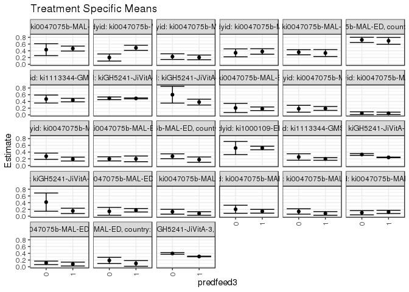

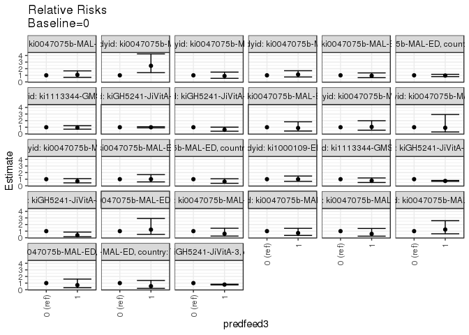

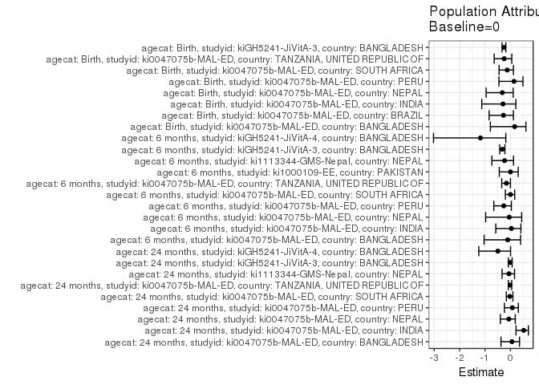

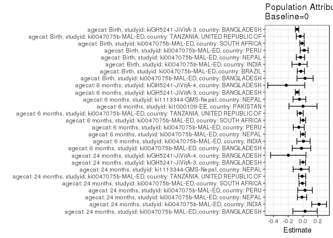

## Results Table

### Parameter: TSM

| agecat | studyid | country | intervention_level | baseline_level | estimate | ci_lower | ci_upper |
| --- | --- | --- | --- | --- | --- | --- | --- |
| Birth | ki0047075b-MAL-ED | BANGLADESH | 0 | NA | 0.1428571 | 0.0266860 | 0.2590283 |
| Birth | ki0047075b-MAL-ED | BANGLADESH | 1 | NA | 0.1756098 | 0.1234160 | 0.2278035 |
| Birth | ki0047075b-MAL-ED | BRAZIL | 0 | NA | 0.1309524 | 0.0586148 | 0.2032899 |
| Birth | ki0047075b-MAL-ED | BRAZIL | 1 | NA | 0.0792079 | 0.0263963 | 0.1320195 |
| Birth | ki0047075b-MAL-ED | INDIA | 0 | NA | 0.2045455 | 0.0850545 | 0.3240364 |
| Birth | ki0047075b-MAL-ED | INDIA | 1 | NA | 0.1447368 | 0.0886609 | 0.2008128 |
| Birth | ki0047075b-MAL-ED | NEPAL | 0 | NA | 0.1388889 | 0.0587730 | 0.2190048 |
| Birth | ki0047075b-MAL-ED | NEPAL | 1 | NA | 0.0808081 | 0.0269644 | 0.1346517 |
| Birth | ki0047075b-MAL-ED | PERU | 0 | NA | 0.1011236 | 0.0383714 | 0.1638758 |
| Birth | ki0047075b-MAL-ED | PERU | 1 | NA | 0.1256831 | 0.0775664 | 0.1737997 |
| Birth | ki0047075b-MAL-ED | SOUTH AFRICA | 0 | NA | 0.1164384 | 0.0642982 | 0.1685785 |
| Birth | ki0047075b-MAL-ED | SOUTH AFRICA | 1 | NA | 0.0804598 | 0.0231805 | 0.1377390 |
| Birth | ki0047075b-MAL-ED | TANZANIA, UNITED REPUBLIC OF | 0 | NA | 0.1884058 | 0.0957500 | 0.2810616 |
| Birth | ki0047075b-MAL-ED | TANZANIA, UNITED REPUBLIC OF | 1 | NA | 0.1000000 | 0.0164942 | 0.1835058 |
| Birth | kiGH5241-JiVitA-3 | BANGLADESH | 0 | NA | 0.3956337 | 0.3706578 | 0.4206095 |
| Birth | kiGH5241-JiVitA-3 | BANGLADESH | 1 | NA | 0.3066778 | 0.2987914 | 0.3145641 |
| 6 months | ki0047075b-MAL-ED | BANGLADESH | 0 | NA | 0.2058824 | 0.0696818 | 0.3420829 |
| 6 months | ki0047075b-MAL-ED | BANGLADESH | 1 | NA | 0.1822660 | 0.1290457 | 0.2354863 |
| 6 months | ki0047075b-MAL-ED | INDIA | 0 | NA | 0.1818182 | 0.0796668 | 0.2839696 |
| 6 months | ki0047075b-MAL-ED | INDIA | 1 | NA | 0.1910112 | 0.1331387 | 0.2488838 |
| 6 months | ki0047075b-MAL-ED | NEPAL | 0 | NA | 0.0495050 | 0.0071094 | 0.0919005 |
| 6 months | ki0047075b-MAL-ED | NEPAL | 1 | NA | 0.0454545 | 0.0098437 | 0.0810654 |
| 6 months | ki0047075b-MAL-ED | PERU | 0 | NA | 0.2758621 | 0.1817705 | 0.3699537 |
| 6 months | ki0047075b-MAL-ED | PERU | 1 | NA | 0.1912568 | 0.1341692 | 0.2483445 |
| 6 months | ki0047075b-MAL-ED | SOUTH AFRICA | 0 | NA | 0.1975309 | 0.1360982 | 0.2589636 |
| 6 months | ki0047075b-MAL-ED | SOUTH AFRICA | 1 | NA | 0.1976744 | 0.1133357 | 0.2820131 |
| 6 months | ki0047075b-MAL-ED | TANZANIA, UNITED REPUBLIC OF | 0 | NA | 0.2751678 | 0.2033091 | 0.3470265 |
| 6 months | ki0047075b-MAL-ED | TANZANIA, UNITED REPUBLIC OF | 1 | NA | 0.1758242 | 0.0974481 | 0.2542002 |
| 6 months | ki1000109-EE | PAKISTAN | 0 | NA | 0.5200000 | 0.3238960 | 0.7161040 |
| 6 months | ki1000109-EE | PAKISTAN | 1 | NA | 0.5202312 | 0.4675191 | 0.5729433 |
| 6 months | ki1113344-GMS-Nepal | NEPAL | 0 | NA | 0.2531646 | 0.1571752 | 0.3491539 |
| 6 months | ki1113344-GMS-Nepal | NEPAL | 1 | NA | 0.1952507 | 0.1552995 | 0.2352018 |
| 6 months | kiGH5241-JiVitA-3 | BANGLADESH | 0 | NA | 0.3274933 | 0.3004635 | 0.3545230 |
| 6 months | kiGH5241-JiVitA-3 | BANGLADESH | 1 | NA | 0.2410624 | 0.2325458 | 0.2495790 |
| 6 months | kiGH5241-JiVitA-4 | BANGLADESH | 0 | NA | 0.4166667 | 0.1460475 | 0.6872858 |
| 6 months | kiGH5241-JiVitA-4 | BANGLADESH | 1 | NA | 0.1558442 | 0.0767551 | 0.2349333 |
| 24 months | ki0047075b-MAL-ED | BANGLADESH | 0 | NA | 0.4333333 | 0.2555836 | 0.6110830 |
| 24 months | ki0047075b-MAL-ED | BANGLADESH | 1 | NA | 0.4662921 | 0.3928297 | 0.5397546 |
| 24 months | ki0047075b-MAL-ED | INDIA | 0 | NA | 0.2000000 | 0.0940517 | 0.3059483 |
| 24 months | ki0047075b-MAL-ED | INDIA | 1 | NA | 0.4882353 | 0.4129274 | 0.5635432 |
| 24 months | ki0047075b-MAL-ED | NEPAL | 0 | NA | 0.2268041 | 0.1432823 | 0.3103259 |
| 24 months | ki0047075b-MAL-ED | NEPAL | 1 | NA | 0.2031250 | 0.1332717 | 0.2729783 |
| 24 months | ki0047075b-MAL-ED | PERU | 0 | NA | 0.3387097 | 0.2206080 | 0.4568114 |
| 24 months | ki0047075b-MAL-ED | PERU | 1 | NA | 0.3795620 | 0.2980968 | 0.4610273 |
| 24 months | ki0047075b-MAL-ED | SOUTH AFRICA | 0 | NA | 0.3576159 | 0.2810027 | 0.4342291 |
| 24 months | ki0047075b-MAL-ED | SOUTH AFRICA | 1 | NA | 0.3333333 | 0.2304518 | 0.4362148 |
| 24 months | ki0047075b-MAL-ED | TANZANIA, UNITED REPUBLIC OF | 0 | NA | 0.7251908 | 0.6485623 | 0.8018194 |
| 24 months | ki0047075b-MAL-ED | TANZANIA, UNITED REPUBLIC OF | 1 | NA | 0.6962025 | 0.5945470 | 0.7978580 |
| 24 months | ki1113344-GMS-Nepal | NEPAL | 0 | NA | 0.4705882 | 0.3518066 | 0.5893698 |
| 24 months | ki1113344-GMS-Nepal | NEPAL | 1 | NA | 0.4404762 | 0.3873282 | 0.4936242 |
| 24 months | kiGH5241-JiVitA-3 | BANGLADESH | 0 | NA | 0.4933009 | 0.4539053 | 0.5326964 |
| 24 months | kiGH5241-JiVitA-3 | BANGLADESH | 1 | NA | 0.4901596 | 0.4761211 | 0.5041981 |
| 24 months | kiGH5241-JiVitA-4 | BANGLADESH | 0 | NA | 0.6000000 | 0.3502268 | 0.8497732 |
| 24 months | kiGH5241-JiVitA-4 | BANGLADESH | 1 | NA | 0.3795620 | 0.2934360 | 0.4656880 |

### Parameter: E(Y)

| agecat | studyid | country | intervention_level | baseline_level | estimate | ci_lower | ci_upper |
| --- | --- | --- | --- | --- | --- | --- | --- |
| Birth | ki0047075b-MAL-ED | BANGLADESH | NA | NA | 0.1708333 | 0.1231182 | 0.2185485 |
| Birth | ki0047075b-MAL-ED | BRAZIL | NA | NA | 0.1027027 | 0.0588397 | 0.1465657 |
| Birth | ki0047075b-MAL-ED | INDIA | NA | NA | 0.1581633 | 0.1069482 | 0.2093783 |
| Birth | ki0047075b-MAL-ED | NEPAL | NA | NA | 0.1052632 | 0.0591304 | 0.1513959 |
| Birth | ki0047075b-MAL-ED | PERU | NA | NA | 0.1176471 | 0.0792874 | 0.1560068 |
| Birth | ki0047075b-MAL-ED | SOUTH AFRICA | NA | NA | 0.1030043 | 0.0638908 | 0.1421178 |
| Birth | ki0047075b-MAL-ED | TANZANIA, UNITED REPUBLIC OF | NA | NA | 0.1512605 | 0.0866122 | 0.2159088 |
| Birth | kiGH5241-JiVitA-3 | BANGLADESH | NA | NA | 0.3156066 | 0.3080361 | 0.3231771 |
| 6 months | ki0047075b-MAL-ED | BANGLADESH | NA | NA | 0.1856540 | 0.1360463 | 0.2352617 |
| 6 months | ki0047075b-MAL-ED | INDIA | NA | NA | 0.1888412 | 0.1384789 | 0.2392035 |
| 6 months | ki0047075b-MAL-ED | NEPAL | NA | NA | 0.0472103 | 0.0199192 | 0.0745014 |
| 6 months | ki0047075b-MAL-ED | PERU | NA | NA | 0.2185185 | 0.1691358 | 0.2679013 |
| 6 months | ki0047075b-MAL-ED | SOUTH AFRICA | NA | NA | 0.1975806 | 0.1479246 | 0.2472367 |
| 6 months | ki0047075b-MAL-ED | TANZANIA, UNITED REPUBLIC OF | NA | NA | 0.2375000 | 0.1835488 | 0.2914512 |
| 6 months | ki1000109-EE | PAKISTAN | NA | NA | 0.5202156 | 0.4693105 | 0.5711208 |
| 6 months | ki1113344-GMS-Nepal | NEPAL | NA | NA | 0.2052402 | 0.1682114 | 0.2422689 |
| 6 months | kiGH5241-JiVitA-3 | BANGLADESH | NA | NA | 0.2489405 | 0.2407278 | 0.2571531 |
| 6 months | kiGH5241-JiVitA-4 | BANGLADESH | NA | NA | 0.1910112 | 0.1139351 | 0.2680874 |
| 24 months | ki0047075b-MAL-ED | BANGLADESH | NA | NA | 0.4615385 | 0.3936268 | 0.5294501 |
| 24 months | ki0047075b-MAL-ED | INDIA | NA | NA | 0.4177778 | 0.3531914 | 0.4823642 |
| 24 months | ki0047075b-MAL-ED | NEPAL | NA | NA | 0.2133333 | 0.1596859 | 0.2669808 |
| 24 months | ki0047075b-MAL-ED | PERU | NA | NA | 0.3668342 | 0.2997053 | 0.4339630 |
| 24 months | ki0047075b-MAL-ED | SOUTH AFRICA | NA | NA | 0.3491379 | 0.2876648 | 0.4106110 |
| 24 months | ki0047075b-MAL-ED | TANZANIA, UNITED REPUBLIC OF | NA | NA | 0.7142857 | 0.6530398 | 0.7755316 |
| 24 months | ki1113344-GMS-Nepal | NEPAL | NA | NA | 0.4455446 | 0.3970186 | 0.4940706 |
| 24 months | kiGH5241-JiVitA-3 | BANGLADESH | NA | NA | 0.4904688 | 0.4770397 | 0.5038978 |
| 24 months | kiGH5241-JiVitA-4 | BANGLADESH | NA | NA | 0.4013158 | 0.3195309 | 0.4831007 |

### Parameter: RR

| agecat | studyid | country | intervention_level | baseline_level | estimate | ci_lower | ci_upper |
| --- | --- | --- | --- | --- | --- | --- | --- |
| Birth | ki0047075b-MAL-ED | BANGLADESH | 0 | 0 | 1.0000000 | 1.0000000 | 1.0000000 |
| Birth | ki0047075b-MAL-ED | BANGLADESH | 1 | 0 | 1.2292683 | 0.5171661 | 2.9218866 |
| Birth | ki0047075b-MAL-ED | BRAZIL | 0 | 0 | 1.0000000 | 1.0000000 | 1.0000000 |
| Birth | ki0047075b-MAL-ED | BRAZIL | 1 | 0 | 0.6048605 | 0.2544616 | 1.4377657 |
| Birth | ki0047075b-MAL-ED | INDIA | 0 | 0 | 1.0000000 | 1.0000000 | 1.0000000 |
| Birth | ki0047075b-MAL-ED | INDIA | 1 | 0 | 0.7076023 | 0.3510418 | 1.4263291 |
| Birth | ki0047075b-MAL-ED | NEPAL | 0 | 0 | 1.0000000 | 1.0000000 | 1.0000000 |
| Birth | ki0047075b-MAL-ED | NEPAL | 1 | 0 | 0.5818182 | 0.2410114 | 1.4045495 |
| Birth | ki0047075b-MAL-ED | PERU | 0 | 0 | 1.0000000 | 1.0000000 | 1.0000000 |
| Birth | ki0047075b-MAL-ED | PERU | 1 | 0 | 1.2428658 | 0.5994618 | 2.5768370 |
| Birth | ki0047075b-MAL-ED | SOUTH AFRICA | 0 | 0 | 1.0000000 | 1.0000000 | 1.0000000 |
| Birth | ki0047075b-MAL-ED | SOUTH AFRICA | 1 | 0 | 0.6910074 | 0.2980105 | 1.6022631 |
| Birth | ki0047075b-MAL-ED | TANZANIA, UNITED REPUBLIC OF | 0 | 0 | 1.0000000 | 1.0000000 | 1.0000000 |
| Birth | ki0047075b-MAL-ED | TANZANIA, UNITED REPUBLIC OF | 1 | 0 | 0.5307692 | 0.2013843 | 1.3988972 |
| Birth | kiGH5241-JiVitA-3 | BANGLADESH | 0 | 0 | 1.0000000 | 1.0000000 | 1.0000000 |
| Birth | kiGH5241-JiVitA-3 | BANGLADESH | 1 | 0 | 0.7751559 | 0.7242990 | 0.8295837 |
| 6 months | ki0047075b-MAL-ED | BANGLADESH | 0 | 0 | 1.0000000 | 1.0000000 | 1.0000000 |
| 6 months | ki0047075b-MAL-ED | BANGLADESH | 1 | 0 | 0.8852920 | 0.4295757 | 1.8244560 |
| 6 months | ki0047075b-MAL-ED | INDIA | 0 | 0 | 1.0000000 | 1.0000000 | 1.0000000 |
| 6 months | ki0047075b-MAL-ED | INDIA | 1 | 0 | 1.0505618 | 0.5548846 | 1.9890265 |
| 6 months | ki0047075b-MAL-ED | NEPAL | 0 | 0 | 1.0000000 | 1.0000000 | 1.0000000 |
| 6 months | ki0047075b-MAL-ED | NEPAL | 1 | 0 | 0.9181818 | 0.2876413 | 2.9309343 |
| 6 months | ki0047075b-MAL-ED | PERU | 0 | 0 | 1.0000000 | 1.0000000 | 1.0000000 |
| 6 months | ki0047075b-MAL-ED | PERU | 1 | 0 | 0.6933060 | 0.4406391 | 1.0908547 |
| 6 months | ki0047075b-MAL-ED | SOUTH AFRICA | 0 | 0 | 1.0000000 | 1.0000000 | 1.0000000 |
| 6 months | ki0047075b-MAL-ED | SOUTH AFRICA | 1 | 0 | 1.0007267 | 0.5902271 | 1.6967266 |
| 6 months | ki0047075b-MAL-ED | TANZANIA, UNITED REPUBLIC OF | 0 | 0 | 1.0000000 | 1.0000000 | 1.0000000 |
| 6 months | ki0047075b-MAL-ED | TANZANIA, UNITED REPUBLIC OF | 1 | 0 | 0.6389708 | 0.3811653 | 1.0711459 |
| 6 months | ki1000109-EE | PAKISTAN | 0 | 0 | 1.0000000 | 1.0000000 | 1.0000000 |
| 6 months | ki1000109-EE | PAKISTAN | 1 | 0 | 1.0004446 | 0.6770209 | 1.4783731 |
| 6 months | ki1113344-GMS-Nepal | NEPAL | 0 | 0 | 1.0000000 | 1.0000000 | 1.0000000 |
| 6 months | ki1113344-GMS-Nepal | NEPAL | 1 | 0 | 0.7712401 | 0.5012746 | 1.1865977 |
| 6 months | kiGH5241-JiVitA-3 | BANGLADESH | 0 | 0 | 1.0000000 | 1.0000000 | 1.0000000 |
| 6 months | kiGH5241-JiVitA-3 | BANGLADESH | 1 | 0 | 0.7360835 | 0.6736612 | 0.8042899 |
| 6 months | kiGH5241-JiVitA-4 | BANGLADESH | 0 | 0 | 1.0000000 | 1.0000000 | 1.0000000 |
| 6 months | kiGH5241-JiVitA-4 | BANGLADESH | 1 | 0 | 0.3740260 | 0.1633044 | 0.8566541 |
| 24 months | ki0047075b-MAL-ED | BANGLADESH | 0 | 0 | 1.0000000 | 1.0000000 | 1.0000000 |
| 24 months | ki0047075b-MAL-ED | BANGLADESH | 1 | 0 | 1.0760588 | 0.6934326 | 1.6698125 |
| 24 months | ki0047075b-MAL-ED | INDIA | 0 | 0 | 1.0000000 | 1.0000000 | 1.0000000 |
| 24 months | ki0047075b-MAL-ED | INDIA | 1 | 0 | 2.4411765 | 1.4059870 | 4.2385474 |
| 24 months | ki0047075b-MAL-ED | NEPAL | 0 | 0 | 1.0000000 | 1.0000000 | 1.0000000 |
| 24 months | ki0047075b-MAL-ED | NEPAL | 1 | 0 | 0.8955966 | 0.5411143 | 1.4822991 |
| 24 months | ki0047075b-MAL-ED | PERU | 0 | 0 | 1.0000000 | 1.0000000 | 1.0000000 |
| 24 months | ki0047075b-MAL-ED | PERU | 1 | 0 | 1.1206117 | 0.7441079 | 1.6876191 |
| 24 months | ki0047075b-MAL-ED | SOUTH AFRICA | 0 | 0 | 1.0000000 | 1.0000000 | 1.0000000 |
| 24 months | ki0047075b-MAL-ED | SOUTH AFRICA | 1 | 0 | 0.9320988 | 0.6401674 | 1.3571576 |
| 24 months | ki0047075b-MAL-ED | TANZANIA, UNITED REPUBLIC OF | 0 | 0 | 1.0000000 | 1.0000000 | 1.0000000 |
| 24 months | ki0047075b-MAL-ED | TANZANIA, UNITED REPUBLIC OF | 1 | 0 | 0.9600266 | 0.8016911 | 1.1496338 |
| 24 months | ki1113344-GMS-Nepal | NEPAL | 0 | 0 | 1.0000000 | 1.0000000 | 1.0000000 |
| 24 months | ki1113344-GMS-Nepal | NEPAL | 1 | 0 | 0.9360119 | 0.7075867 | 1.2381781 |
| 24 months | kiGH5241-JiVitA-3 | BANGLADESH | 0 | 0 | 1.0000000 | 1.0000000 | 1.0000000 |
| 24 months | kiGH5241-JiVitA-3 | BANGLADESH | 1 | 0 | 0.9936321 | 0.9141158 | 1.0800654 |
| 24 months | kiGH5241-JiVitA-4 | BANGLADESH | 0 | 0 | 1.0000000 | 1.0000000 | 1.0000000 |
| 24 months | kiGH5241-JiVitA-4 | BANGLADESH | 1 | 0 | 0.6326034 | 0.3951593 | 1.0127235 |

### Parameter: PAR

| agecat | studyid | country | intervention_level | baseline_level | estimate | ci_lower | ci_upper |
| --- | --- | --- | --- | --- | --- | --- | --- |
| Birth | ki0047075b-MAL-ED | BANGLADESH | 0 | NA | 0.0279762 | -0.0808182 | 0.1367706 |
| Birth | ki0047075b-MAL-ED | BRAZIL | 0 | NA | -0.0282497 | -0.0772885 | 0.0207892 |
| Birth | ki0047075b-MAL-ED | INDIA | 0 | NA | -0.0463822 | -0.1488053 | 0.0560410 |
| Birth | ki0047075b-MAL-ED | NEPAL | 0 | NA | -0.0336257 | -0.0896765 | 0.0224250 |
| Birth | ki0047075b-MAL-ED | PERU | 0 | NA | 0.0165235 | -0.0366963 | 0.0697432 |
| Birth | ki0047075b-MAL-ED | SOUTH AFRICA | 0 | NA | -0.0134341 | -0.0424421 | 0.0155740 |
| Birth | ki0047075b-MAL-ED | TANZANIA, UNITED REPUBLIC OF | 0 | NA | -0.0371453 | -0.0901422 | 0.0158516 |
| Birth | kiGH5241-JiVitA-3 | BANGLADESH | 0 | NA | -0.0800270 | -0.1035604 | -0.0564936 |
| 6 months | ki0047075b-MAL-ED | BANGLADESH | 0 | NA | -0.0202283 | -0.1454840 | 0.1050273 |
| 6 months | ki0047075b-MAL-ED | INDIA | 0 | NA | 0.0070230 | -0.0826704 | 0.0967165 |
| 6 months | ki0047075b-MAL-ED | NEPAL | 0 | NA | -0.0022946 | -0.0336625 | 0.0290732 |
| 6 months | ki0047075b-MAL-ED | PERU | 0 | NA | -0.0573436 | -0.1320863 | 0.0173992 |
| 6 months | ki0047075b-MAL-ED | SOUTH AFRICA | 0 | NA | 0.0000498 | -0.0361329 | 0.0362325 |
| 6 months | ki0047075b-MAL-ED | TANZANIA, UNITED REPUBLIC OF | 0 | NA | -0.0376678 | -0.0784457 | 0.0031102 |
| 6 months | ki1000109-EE | PAKISTAN | 0 | NA | 0.0002156 | -0.1891656 | 0.1895969 |
| 6 months | ki1113344-GMS-Nepal | NEPAL | 0 | NA | -0.0479244 | -0.1339852 | 0.0381365 |
| 6 months | kiGH5241-JiVitA-3 | BANGLADESH | 0 | NA | -0.0785528 | -0.1040657 | -0.0530398 |
| 6 months | kiGH5241-JiVitA-4 | BANGLADESH | 0 | NA | -0.2256554 | -0.4758250 | 0.0245141 |
| 24 months | ki0047075b-MAL-ED | BANGLADESH | 0 | NA | 0.0282051 | -0.1363944 | 0.1928047 |
| 24 months | ki0047075b-MAL-ED | INDIA | 0 | NA | 0.2177778 | 0.1182356 | 0.3173200 |
| 24 months | ki0047075b-MAL-ED | NEPAL | 0 | NA | -0.0134708 | -0.0754318 | 0.0484902 |
| 24 months | ki0047075b-MAL-ED | PERU | 0 | NA | 0.0281245 | -0.0706837 | 0.1269327 |
| 24 months | ki0047075b-MAL-ED | SOUTH AFRICA | 0 | NA | -0.0084780 | -0.0532881 | 0.0363322 |
| 24 months | ki0047075b-MAL-ED | TANZANIA, UNITED REPUBLIC OF | 0 | NA | -0.0109051 | -0.0588327 | 0.0370225 |
| 24 months | ki1113344-GMS-Nepal | NEPAL | 0 | NA | -0.0250437 | -0.1332761 | 0.0831887 |
| 24 months | kiGH5241-JiVitA-3 | BANGLADESH | 0 | NA | -0.0028321 | -0.0399063 | 0.0342421 |
| 24 months | kiGH5241-JiVitA-4 | BANGLADESH | 0 | NA | -0.1986842 | -0.4379272 | 0.0405588 |

### Parameter: PAF

| agecat | studyid | country | intervention_level | baseline_level | estimate | ci_lower | ci_upper |
| --- | --- | --- | --- | --- | --- | --- | --- |
| Birth | ki0047075b-MAL-ED | BANGLADESH | 0 | NA | 0.1637631 | -0.7885922 | 0.6090265 |
| Birth | ki0047075b-MAL-ED | BRAZIL | 0 | NA | -0.2750627 | -0.8392541 | 0.1160630 |
| Birth | ki0047075b-MAL-ED | INDIA | 0 | NA | -0.2932551 | -1.1278725 | 0.2139995 |
| Birth | ki0047075b-MAL-ED | NEPAL | 0 | NA | -0.3194444 | -0.9562722 | 0.1100760 |
| Birth | ki0047075b-MAL-ED | PERU | 0 | NA | 0.1404494 | -0.4518745 | 0.4911219 |
| Birth | ki0047075b-MAL-ED | SOUTH AFRICA | 0 | NA | -0.1304224 | -0.4460720 | 0.1163270 |
| Birth | ki0047075b-MAL-ED | TANZANIA, UNITED REPUBLIC OF | 0 | NA | -0.2455717 | -0.6384953 | 0.0531259 |
| Birth | kiGH5241-JiVitA-3 | BANGLADESH | 0 | NA | -0.2535657 | -0.3304277 | -0.1811443 |
| 6 months | ki0047075b-MAL-ED | BANGLADESH | 0 | NA | -0.1089572 | -1.0370945 | 0.3963038 |
| 6 months | ki0047075b-MAL-ED | INDIA | 0 | NA | 0.0371901 | -0.5767336 | 0.4120738 |
| 6 months | ki0047075b-MAL-ED | NEPAL | 0 | NA | -0.0486049 | -0.9750288 | 0.4432627 |
| 6 months | ki0047075b-MAL-ED | PERU | 0 | NA | -0.2624196 | -0.6532988 | 0.0360464 |
| 6 months | ki0047075b-MAL-ED | SOUTH AFRICA | 0 | NA | 0.0002520 | -0.2007217 | 0.1675872 |
| 6 months | ki0047075b-MAL-ED | TANZANIA, UNITED REPUBLIC OF | 0 | NA | -0.1586012 | -0.3424495 | 0.0000691 |
| 6 months | ki1000109-EE | PAKISTAN | 0 | NA | 0.0004145 | -0.4387579 | 0.3055321 |
| 6 months | ki1113344-GMS-Nepal | NEPAL | 0 | NA | -0.2335039 | -0.7318254 | 0.1214288 |
| 6 months | kiGH5241-JiVitA-3 | BANGLADESH | 0 | NA | -0.3155484 | -0.4223747 | -0.2167453 |
| 6 months | kiGH5241-JiVitA-4 | BANGLADESH | 0 | NA | -1.1813726 | -3.0281473 | -0.1812841 |
| 24 months | ki0047075b-MAL-ED | BANGLADESH | 0 | NA | 0.0611111 | -0.3728112 | 0.3578779 |
| 24 months | ki0047075b-MAL-ED | INDIA | 0 | NA | 0.5212766 | 0.2195716 | 0.7063458 |
| 24 months | ki0047075b-MAL-ED | NEPAL | 0 | NA | -0.0631443 | -0.3968919 | 0.1908638 |
| 24 months | ki0047075b-MAL-ED | PERU | 0 | NA | 0.0766681 | -0.2361240 | 0.3103105 |
| 24 months | ki0047075b-MAL-ED | SOUTH AFRICA | 0 | NA | -0.0242826 | -0.1610232 | 0.0963534 |
| 24 months | ki0047075b-MAL-ED | TANZANIA, UNITED REPUBLIC OF | 0 | NA | -0.0152672 | -0.0846883 | 0.0497110 |
| 24 months | ki1113344-GMS-Nepal | NEPAL | 0 | NA | -0.0562091 | -0.3294044 | 0.1608439 |
| 24 months | kiGH5241-JiVitA-3 | BANGLADESH | 0 | NA | -0.0057742 | -0.0842772 | 0.0670450 |
| 24 months | kiGH5241-JiVitA-4 | BANGLADESH | 0 | NA | -0.4950820 | -1.2461071 | 0.0048248 |